# Survey Analysis With NHANES Data

Qinlu (Claire) Wang

BCBB

This is the practical tutorial for the Survey Analysis Training. 7 topics will be covered:

1. Importing NHANES to R
2. Sampling
3. Simple summary statistics
4. Ratio Estimations and Regression Models
5. Tests in contingency tables
6. Multiple Imputation
7. Graphics

### 1. Importing NHANES to R

National Center for Health Statistics (NCHS) has been conducting surveys combining interviews with health/laboratory and physical examination studies since 1959. The end-product, recently known as, National Health and Nutrition Examination Surveys (NHANES) provide cross-sectional data of the health and nutrition of the United States population. This information source has been central to formulating nationwide public health policies and practices.

R package **nhanesA** provides a convenient way to download and analyze NHANES survey data.

```r
library(haven) # For reading SAS XPT file from NHANES website
library(survey) # For using survey weights
library(dplyr) # For data wrangling
library(nhanesA)
```

Within the CDC website, NHANES data are available in 5 categories

- Demographics (DEMO)
- Dietary (DIET)
- Examination (EXAM)
- Laboratory (LAB)
- Questionnaire (Q)

We can obtain the summaries of the downloaded data as follows (see below):

```r
demo <- nhanes('DEMO_I')
```

```
## Processing SAS dataset DEMO_I     ..
```

```r
names(demo)
```

```
##  [1] "SEQN"     "SDDSRVYR" "RIDSTATR" "RIAGENDR" "RIDAGEYR" "RIDAGEMN"
##  [7] "RIDRETH1" "RIDRETH3" "RIDEXMON" "RIDEXAGM" "DMQMILIZ" "DMQADFC"
## [13] "DMDBORN4" "DMDCITZN" "DMDYRSUS" "DMDEDUC3" "DMDEDUC2" "DMDMARTL"
## [19] "RIDEXPRG" "SIALANG"  "SIAPROXY" "SIAINTRP" "FIALANG"  "FIAPROXY"
## [25] "FIAINTRP" "MIALANG"  "MIAPROXY" "MIAINTRP" "AIALANGA" "DMDHHSIZ"
## [31] "DMDFMSIZ" "DMDHHSZA" "DMDHHSZB" "DMDHHSZE" "DMDHRGND" "DMDHRAGE"
## [37] "DMDHRBR4" "DMDHREDU" "DMDHRMAR" "DMDHSEDU" "WTINT2YR" "WTMEC2YR"
## [43] "SDMVPSU"  "SDMVSTRA" "INDHHIN2" "INDFMIN2" "INDFMPIR"
```

The descriptions of this dataset: https://wwwn.cdc.gov/Nchs/Nhanes/2015-2016/DEMO_i.htm

```r
table(demo$DMDHSEDU)
```

```
##
##    1    2    3    4    5    7    9
##  619  511  980 1462 1629    2   23
```

```r
cumsum(table(demo$DMDHSEDU))
```

```
##    1    2    3    4    5    7    9
##  619 1130 2110 3572 5201 5203 5226
```

```r
sum(is.na(demo$DMDHSEDU))
```

```
## [1] 4745
```

```r
summary(demo)
```

```
##       SEQN          SDDSRVYR    RIDSTATR        RIAGENDR        RIDAGEYR
##  Min.   :83732   Min.   :9   Min.   :1.000   Min.   :1.000   Min.   : 0.0
##  1st Qu.:86224   1st Qu.:9   1st Qu.:2.000   1st Qu.:1.000   1st Qu.: 9.0
##  Median :88717   Median :9   Median :2.000   Median :2.000   Median :27.0
##  Mean   :88717   Mean   :9   Mean   :1.957   Mean   :1.509   Mean   :31.9
##  3rd Qu.:91210   3rd Qu.:9   3rd Qu.:2.000   3rd Qu.:2.000   3rd Qu.:53.0
##  Max.   :93702   Max.   :9   Max.   :2.000   Max.   :2.000   Max.   :80.0
##
##     RIDAGEMN        RIDRETH1        RIDRETH3        RIDEXMON
##  Min.   : 0.00   Min.   :1.000   Min.   :1.000   Min.   :1.000
##  1st Qu.: 5.00   1st Qu.:2.000   1st Qu.:2.000   1st Qu.:1.000
##  Median :10.00   Median :3.000   Median :3.000   Median :2.000
##  Mean   :10.79   Mean   :3.007   Mean   :3.213   Mean   :1.519
##  3rd Qu.:17.00   3rd Qu.:4.000   3rd Qu.:4.000   3rd Qu.:2.000
##  Max.   :24.00   Max.   :5.000   Max.   :7.000   Max.   :2.000
##  NA's   :9276                                    NA's   :427
##     RIDEXAGM        DMQMILIZ        DMQADFC         DMDBORN4
##  Min.   :  0.0   Min.   :1.000   Min.   :1.000   Min.   : 1.000
##  1st Qu.: 41.0   1st Qu.:2.000   1st Qu.:1.000   1st Qu.: 1.000
##  Median :100.0   Median :2.000   Median :2.000   Median : 1.000
##  Mean   :104.5   Mean   :1.914   Mean   :1.529   Mean   : 1.244
##  3rd Qu.:162.0   3rd Qu.:2.000   3rd Qu.:2.000   3rd Qu.: 1.000
##  Max.   :239.0   Max.   :2.000   Max.   :7.000   Max.   :99.000
##  NA's   :5911    NA's   :3822    NA's   :9444
##     DMDCITZN        DMDYRSUS         DMDEDUC3         DMDEDUC2
##  Min.   :1.000   Min.   : 1.000   Min.   : 0.000   Min.   :1.00
##  1st Qu.:1.000   1st Qu.: 3.000   1st Qu.: 2.000   1st Qu.:3.00
##  Median :1.000   Median : 5.000   Median : 5.000   Median :4.00
##  Mean   :1.128   Mean   : 8.752   Mean   : 5.989   Mean   :3.44
##  3rd Qu.:1.000   3rd Qu.: 7.000   3rd Qu.: 9.000   3rd Qu.:4.00
##  Max.   :9.000   Max.   :99.000   Max.   :99.000   Max.   :9.00
##  NA's   :2       NA's   :7735     NA's   :7324     NA's   :4252
##     DMDMARTL         RIDEXPRG        SIALANG         SIAPROXY
##  Min.   : 1.000   Min.   :1.000   Min.   :1.000   Min.   :1.00
##  1st Qu.: 1.000   1st Qu.:2.000   1st Qu.:1.000   1st Qu.:1.00
##  Median : 1.000   Median :2.000   Median :1.000   Median :2.00
##  Mean   : 2.651   Mean   :2.018   Mean   :1.139   Mean   :1.63
##  3rd Qu.: 5.000   3rd Qu.:2.000   3rd Qu.:1.000   3rd Qu.:2.00
##  Max.   :99.000   Max.   :3.000   Max.   :2.000   Max.   :2.00
##  NA's   :4252     NA's   :8683                    NA's   :1
```

[output cut: 41 more lines]

```
##  Min.   :1.000   Min.   :119.0   Min.   : 1.00   Min.   : 1.00
##  1st Qu.:1.000   1st Qu.:123.0   1st Qu.: 6.00   1st Qu.: 5.00
##  Median :1.000   Median :126.0   Median : 8.00   Median : 8.00
##  Mean   :1.486   Mean   :126.3   Mean   :11.52   Mean   :11.25
##  3rd Qu.:2.000   3rd Qu.:130.0   3rd Qu.:14.00   3rd Qu.:14.00
##  Max.   :2.000   Max.   :133.0   Max.   :99.00   Max.   :99.00
##                                  NA's   :345     NA's   :329
##     INDFMPIR
##  Min.   :0.000
##  1st Qu.:0.970
##  Median :1.820
##  Mean   :2.269
##  3rd Qu.:3.480
##  Max.   :5.000
##  NA's   :1052
```

```r
head(demo)
```

```
##    SEQN SDDSRVYR RIDSTATR RIAGENDR RIDAGEYR RIDAGEMN RIDRETH1 RIDRETH3 RIDEXMON
## 1 83732        9        2        1       62       NA        3        3        1
## 2 83733        9        2        1       53       NA        3        3        1
## 3 83734        9        2        1       78       NA        3        3        2
## 4 83735        9        2        2       56       NA        3        3        2
## 5 83736        9        2        2       42       NA        4        4        2
## 6 83737        9        2        2       72       NA        1        1        1
##   RIDEXAGM DMQMILIZ DMQADFC DMDBORN4 DMDCITZN DMDYRSUS DMDEDUC3 DMDEDUC2
## 1       NA        2      NA        1        1       NA       NA        5
## 2       NA        2      NA        2        2        7       NA        3
## 3       NA        1       2        1        1       NA       NA        3
## 4       NA        2      NA        1        1       NA       NA        5
## 5       NA        2      NA        1        1       NA       NA        4
## 6       NA        2      NA        2        2        2       NA        2
##   DMDMARTL RIDEXPRG SIALANG SIAPROXY SIAINTRP FIALANG FIAPROXY FIAINTRP MIALANG
```

[output cut: 27 more lines]

```r
dim(demo)
```

```
## [1] 9971   47
```

### 2. Sampling

Survey designs are specified using the **svydesign** function. The main arguments to the function are id to specify sampling units (PSUs and optionally later stages), strata to specify strata, weights to specify sampling weights, and fpc to specify finite population size corrections. These arguments should be given as formulas, referring to columns in a data frame given as the data argument.

The resulting survey design object contains all the data and meta-data needed for analysis, and will be supplied as an argument to analysis functions.

The survey package contains several subsamples from the California Academic Performance Index, in the api data set. More info about these datasets: https://r-survey.r-forge.r-project.org/survey/html/api.html.

First, we load these data:

```r
library(survey)
data(api)
```

#### 2.1 Simple Sampling

The survey package includes a simple random sample from the API population, in the data set apisrs. The variable fpc in this data set contains the number 6194, the number of schools in California.

In the call to svydesign():

- The *data=apisrs* argument specifies where the data are stored.
- The argument *id=~1* says that individual schools were sampled.
- *fpc=~fpc* says that the variable called fpc in the data set contains the population size (the ~ notation denotes a variable in the supplied data set).

The sampling weights can be worked out from the population size and sample size, so they do not need to be specified. The survey design object has been called *srs_design*, and when it is printed it will display some basic identifying information. The functions *svymean()* and *svytota1()* estimate the population mean and population total, respectively.

```r
srs_design <- svydesign(id=~1, fpc=~fpc, data=apisrs)
srs_design
```

```
## Independent Sampling design
## svydesign(id = ~1, fpc = ~fpc, data = apisrs)
```

```r
svytotal(~enroll, srs_design)
```

```
##          total     SE
## enroll 3621074 169520
```

```r
svymean(~enroll, srs_design)
```

```
##          mean     SE
## enroll 584.61 27.368
```

The estimated population total is 3.6 million students enrolled, with a standard error of 169,000; the estimated mean school size is about 585, with a standard error of 27. The true values are 3.8 million and 619, respectively, so the standard errors do give an accurate representation of the uncertainty in the estimates.

If the population size is not specified it is necessary to specify the sampling probabilities or sampling weights. The variable pw in the data set contains the sampling weight, 6194/200 = 30.97.

```r
nofpc <- svydesign(id=~1, weights=~pw, data=apisrs)
nofpc
```

```
## Independent Sampling design (with replacement)
## svydesign(id = ~1, weights = ~pw, data = apisrs)
```

```r
svytotal(~enroll, nofpc)
```

```
##          total     SE
## enroll 3621074 172325
```

```r
svymean(~enroll, nofpc)
```

```
##          mean     SE
## enroll 584.61 27.821
```

When the design object is printed, the lack of population size information is indicated by “(with replacement)” in the output. The estimated mean and total are the same, but the standard errors are very slightly larger.

#### 2.2 Stratified Sampling

The *apistrat* data frame has stratified independent sample

```r
dstrat <- svydesign(id=~1,strata=~stype, weights=~pw, data=apistrat, fpc=~fpc)
dstrat
```

```
## Stratified Independent Sampling design
## svydesign(id = ~1, strata = ~stype, weights = ~pw, data = apistrat,
##     fpc = ~fpc)
```

stratified on stype (Elementary/Middle/High School), with sampling weights pw. The fpc variable contains the population size for the stratum. As the schools are sampled independently, each record in the data frame is a separate PSU. This is indicated by id=~1. Since the sampling weights could have been determined from the population size an equivalent declaration would be

```r
dstrat <- svydesign(id=~1,strata=~stype,  data=apistrat, fpc=~fpc)
dstrat
```

```
## Stratified Independent Sampling design
## svydesign(id = ~1, strata = ~stype, data = apistrat, fpc = ~fpc)
```

#### 2.3 Cluster Sampling

The **apiclus1** data frame is a cluster sample: all schools in a random sample of school districts.

```r
dclus1 <- svydesign(id=~dnum, weights=~pw, data=apiclus1, fpc=~fpc)
dclus1
```

```
## 1 - level Cluster Sampling design
## With (15) clusters.
## svydesign(id = ~dnum, weights = ~pw, data = apiclus1, fpc = ~fpc)
```

```r
svytotal(~enroll, dclus1)
```

```
##          total     SE
## enroll 3404940 932235
```

```r
svymean(~enroll, dclus1)
```

```
##          mean     SE
## enroll 549.72 45.191
```

There is no strata argument as the sampling was not stratified. The variable dnum identifies school districts (PSUs) and is specified as the id argument. Again, the weights argument is optional, as the sampling weights can be computed from the population size. To specify sampling with replacement, simply omit the fpc argument:

```r
dclus1 <- svydesign(id=~dnum, weights=~pw, data=apiclus1)
dclus1
```

```
## 1 - level Cluster Sampling design (with replacement)
## With (15) clusters.
## svydesign(id = ~dnum, weights = ~pw, data = apiclus1)
```

```r
svytotal(~enroll, dclus1)
```

```
##          total     SE
## enroll 3404940 941611
```

```r
svymean(~enroll, dclus1)
```

```
##          mean     SE
## enroll 549.72 45.646
```

#### 2.4 Application with NHANES data

Copy and rename variables so they are more intuitive. “fpl” is percent of the federal poverty level. It ranges from 0 to 5.

```r
demo$fpl        <- demo$INDFMPIR
demo$age        <- demo$RIDAGEYR
demo$gender     <- demo$RIAGENDR
demo$persWeight <- demo$WTINT2YR
demo$psu        <- demo$SDMVPSU
demo$strata     <- demo$SDMVSTRA
nhanesAnalysis <- demo %>%
                    select(fpl,
                           age,
                           gender,
                           persWeight,
                           psu,
                           strata)
```

Convert “gender” to a factor variable. We need to do this so it isn’t treated as a continuous variable in our analyses

```r
nhanesAnalysis$gender <- as.factor(nhanesAnalysis$gender)
```

```r
# Here we use "svydesign" to assign the weights. We will use this new design variable "nhanesDesign" when running our analyses.

nhanesDesign <- svydesign(id      = ~psu,
                          strata  = ~strata,
                          weights = ~persWeight,
                          nest    = TRUE,
                          data    = nhanesAnalysis)

# Here we use "subset" to tell "nhanesDesign" that we want to only look at a specific subpopulation (i.e., those age between 18-79 years). This is important to do. If you don't do this and just restrict it in a different way your estimates won't have correct SEs.

ageDesign <- subset(nhanesDesign, age > 17 &
                                  age < 80)

nhanesDesign
```

```
## Stratified 1 - level Cluster Sampling design (with replacement)
## With (30) clusters.
## svydesign(id = ~psu, strata = ~strata, weights = ~persWeight,
##     nest = TRUE, data = nhanesAnalysis)
```

```r
ageDesign
```

```
## Stratified 1 - level Cluster Sampling design (with replacement)
## With (30) clusters.
## subset(nhanesDesign, age > 17 & age < 80)
```

```r
svymean(~age, ageDesign, na.rm = TRUE)
```

```
##       mean     SE
## age 45.648 0.5131
```

```r
svymean(~gender, ageDesign, na.rm = TRUE)
```

```
##            mean    SE
## gender1 0.48601 0.006
## gender2 0.51399 0.006
```

### 3. Simple summary statistics

```r
dclus1
```

```
## 1 - level Cluster Sampling design (with replacement)
## With (15) clusters.
## svydesign(id = ~dnum, weights = ~pw, data = apiclus1)
```

All the analysis functions take a survey design object as one of the arguments, and use a model formula to specify variables for analysis. First look at svymean.

```r
svymean(~api00, dclus1)
```

```
##         mean     SE
## api00 644.17 23.779
```

This asks for the mean (and standard error of the mean) for the variable api00, the year 2000 Academic Performance Index. We can ask for means of more than one variable at a time:

```r
svymean(~api00+api99+stype, dclus1)
```

```
##              mean      SE
## api00  644.169399 23.7790
## api99  606.978142 24.4687
## stypeE   0.786885  0.0468
## stypeH   0.076503  0.0271
## stypeM   0.136612  0.0299
```

Here we have the means of 1999 and 2000 API and school type (elementary, middle, high). Note that for the factor variable stype the proportion in each category is reported.

Totals are estimated with svytotal. Here we estimate the total number of students enrolled, and the total number of schools by type, across the California population.

```r
svytotal(~enroll+stype, dclus1)
```

```
##             total        SE
## enroll 3404940.13 941610.74
## stypeE    4873.97   1346.73
## stypeH     473.86    160.30
## stypeM     846.17    169.24
```

Note again that totals for factor variables are interpreted as total numbers in each category.

The functions for totals and means can also report the design effect, with the option deff=TRUE

```r
svytotal(~enroll+stype, dclus1, deff=TRUE)
```

```
##             total         SE    DEff
## enroll 3404940.13  941610.74 31.9436
## stypeE    4873.97    1346.73 52.8675
## stypeH     473.86     160.30  1.7778
## stypeM     846.17     169.23  1.1870
```

though this is not currently available with replicate weights.

Ratio estimates are computed with svyratio. This has two formula arguments, specifying one or more numerator variables and one or more denominator variables. In this example we estimate the proportion of students who took the API test from the number who took the test and the number enrolled.

```r
svyratio(~api.stu,~enroll, dclus1)
```

```
## Ratio estimator: svyratio.survey.design2(~api.stu, ~enroll, dclus1)
## Ratios=
##            enroll
## api.stu 0.8497087
## SEs=
##             enroll
## api.stu 0.00847064
```

Quantiles are a more difficult estimation problem. It is easy enough to find a point estimate, but many confidence interval methods fail. There are two confidence interval calculation methods for quantiles in objects created with svydesign. The default method is substantially faster but probably less accurate for tail quantiles or for small data sets.

In addition to specifying the variables and the design object, it is necessary to specify which quantiles to estimate. Here we estimate the median and quartiles.

```r
svyquantile(~api00, dclus1, c(.25,.5,.75), ci=TRUE)
```

```
## $api00
##      quantile ci.2.5 ci.97.5       se
## 0.25      552    491     628 31.93791
## 0.5       652    559     715 36.36725
## 0.75      719    696     777 18.88300
##
## attr(,"hasci")
## [1] TRUE
## attr(,"class")
## [1] "newsvyquantile"
```

```r
dclus1<-svydesign(id=~dnum, weights=~pw, data=apiclus1, fpc=~fpc)
(qapi<-svyquantile(~api00, dclus1, c(.25,.5,.75),ci=TRUE, interval.type="score"))
```

```
## $api00
##      quantile ci.2.5 ci.97.5       se
## 0.25      552    512     638 29.37355
## 0.5       652    564     701 31.93791
## 0.75      719    662     749 20.28174
##
## attr(,"hasci")
## [1] TRUE
## attr(,"class")
## [1] "newsvyquantile"
```

```r
SE(qapi)
```

```
## api00.0.25  api00.0.5 api00.0.75
##   29.37355   31.93791   20.28174
```

The confidence intervals are not symmetric and so cannot be generated by adding and subtracting 1.96 standard errors. Nonetheless, a reasonable estimate of the standard error is the length of the confidence interval divided by (2x1.96).

The syntax for replicate weights is similar. Again, there are two methods of variance estimation. The default is valid for all types of replicate weights and is based on computing a confidence interval for the probability and transforming it. The alternative, directly using the variance of replicates, is not valid for jackknife weights.

##### Tables of summary statistics

As discussed in earlier examples, svyby can be used to estimate statistics in subpopulations and svymean and svytotal give proportions or totals in subpopulations when used on factor variables. In this example we see how to construct reasonably attractive tables of summary statistics using the output from these functions. These examples use the dclus1 survey design object created in an earlier example.

The first example shows the estimation of proportions in the cells of a contingency table: school type (elementary, middle, high) by whether the school met its “comparable improvement” target. The first step is to construct a single factor variable that specifies all the cells in the table and use svymean to estimate proportions

```r
a <- svymean(~interaction(stype, comp.imp), design = dclus1)
a
```

```
##                                       mean     SE
## interaction(stype, comp.imp)E.No  0.174863 0.0260
## interaction(stype, comp.imp)H.No  0.038251 0.0161
## interaction(stype, comp.imp)M.No  0.060109 0.0246
## interaction(stype, comp.imp)E.Yes 0.612022 0.0417
## interaction(stype, comp.imp)H.Yes 0.038251 0.0161
## interaction(stype, comp.imp)M.Yes 0.076503 0.0217
```

This contains all the numbers we need, but the formatting leaves something to be desired. The ftable function reshapes output like this into a flattened table. We specify the variable names and the labels for each level in the rownames argument:

```r
b <- ftable(a, rownames = list(stype = c("E", "H",
     "M"), comp.imp = c("No", "Yes")))
b
```

```
##               stype          E          H          M
## comp.imp
## No       mean       0.17486339 0.03825137 0.06010929
##          SE         0.02599552 0.01607602 0.02457177
## Yes      mean       0.61202186 0.03825137 0.07650273
##          SE         0.04167572 0.01605469 0.02167084
```

The major remaining fault in the table is that too many digits are given. We can convert to percentages and then round to one decimal place:

```r
round(100 * b, 1)
```

```
##               stype    E    H    M
## comp.imp
## No       mean       17.5  3.8  6.0
##          SE          2.6  1.6  2.5
## Yes      mean       61.2  3.8  7.7
##          SE          4.2  1.6  2.2
```

### 4. Ratio Estimations and Regression Models

#### Ratio Estimation

##### 1) Estimating Ratios

```r
svyratio(~api.stu,~enroll, dclus1)
```

```
## Ratio estimator: svyratio.survey.design2(~api.stu, ~enroll, dclus1)
## Ratios=
##            enroll
## api.stu 0.8497087
## SEs=
##              enroll
## api.stu 0.008386297
```

The true proportion based on the population data is 0.8387, so the estimate is quite accurate.

##### 2) Ratios for Subpopulation estimates

Suppose that in the artificial fpc data set we want to estimate the mean of x when x>4.

```r
data(fpc)
dfpc<-svydesign(id=~psuid,strat=~stratid,weight=~weight,data=fpc,nest=TRUE)
dsub<-subset(dfpc,x>4)
svymean(~x,design=dsub)
```

```
##    mean     SE
## x 6.195 0.7555
```

The subset function constructs a survey design object with information about this subpopulation and svymean computes the mean. The same operation can be done for a set of subpopulations with svyby.

```r
svyby(~x,~I(x>4),design=dfpc, svymean)
```

```
##       I(x > 4)        x        se
## FALSE    FALSE 3.314286 0.3117042
## TRUE      TRUE 6.195000 0.7555129
```

The classical derivation of the domain mean estimator is as a ratio where the numerator is X for observations in the domain and 0 otherwise and the denominator is 1 for observations in the domain and 0 otherwise

```r
svyratio(~I(x*(x>4)),~as.numeric(x>4), dfpc)
```

```
## Ratio estimator: svyratio.survey.design2(~I(x * (x > 4)), ~as.numeric(x > 4),
##     dfpc)
## Ratios=
##                as.numeric(x > 4)
## I(x * (x > 4))             6.195
## SEs=
##                as.numeric(x > 4)
## I(x * (x > 4))         0.7555129
```

More approaches for ratios for Subpopulation estimates: https://cran.r-project.org/web/packages/survey/vignettes/domain.pdf

##### 3) Ratio estimators of totals

```r
r <- svyratio(~api.stu, ~enroll, dstrat)
predict(r, total= 3811472)
```

```
## $total
##          enroll
## api.stu 3190038
##
## $se
##           enroll
## api.stu 29565.98
```

#### Regression Models

Generalized linear models, including the linear model, are estimated by svyglm.

In this example we use the dclus2 two-stage cluster sample from the California Academic Performance Index. The syntax and options for svyglm are the same for designs with and without replicate weights.

```r
dclus2<-svydesign(id=~dnum+snum, fpc=~fpc1+fpc2, data=apiclus2)
```

The outcome variable is 2000 API, predicted by the proportions of students learning English (ell), receiving subsidized meals (meals) and having moved to the school within the past year (mobility). This is a linear regression model, so no family argument to svyglm is needed.

```r
summary(svyglm(api00 ~ ell + meals + mobility, design = dclus2))
```

```
##
## Call:
## svyglm(formula = api00 ~ ell + meals + mobility, design = dclus2)
##
## Survey design:
## svydesign(id = ~dnum + snum, fpc = ~fpc1 + fpc2, data = apiclus2)
##
## Coefficients:
##             Estimate Std. Error t value Pr(>|t|)
## (Intercept) 811.4907    30.2338  26.840   <2e-16 ***
## ell          -2.0592     1.3798  -1.492    0.144
## meals        -1.7772     1.0830  -1.641    0.110
## mobility      0.3253     0.6103   0.533    0.597
## ---
## Signif. codes:  0 '***' 0.001 '**' 0.01 '*' 0.05 '.' 0.1 ' ' 1
##
## (Dispersion parameter for gaussian family taken to be 8363.101)
##
## Number of Fisher Scoring iterations: 2
```

A useful property of regression models is that they provide another way to get domain estimates. Suppose we want the mean of api00 for each school type:

```r
summary(svyglm(api00~stype-1, dclus2))
```

```
##
## Call:
## svyglm(formula = api00 ~ stype - 1, design = dclus2)
##
## Survey design:
## svydesign(id = ~dnum + snum, fpc = ~fpc1 + fpc2, data = apiclus2)
##
## Coefficients:
##        Estimate Std. Error t value Pr(>|t|)
## stypeE   692.81      29.93   23.15   <2e-16 ***
## stypeH   598.34      17.69   33.82   <2e-16 ***
## stypeM   642.35      45.09   14.25   <2e-16 ***
## ---
## Signif. codes:  0 '***' 0.001 '**' 0.01 '*' 0.05 '.' 0.1 ' ' 1
##
## (Dispersion parameter for gaussian family taken to be 17528.44)
##
## Number of Fisher Scoring iterations: 2
```

```r
svyby(~api00,~stype,dclus2,svymean, keep.var=TRUE)
```

```
##   stype    api00       se
## E     E 692.8104 29.92660
## H     H 598.3407 17.69417
## M     M 642.3520 45.09132
```

This equivalence helps in thinking about domain estimators and how they handle more complex designs.

More resources for logistic regression:

- https://rpubs.com/corey_sparks/577954
- https://stats.oarc.ucla.edu/r/seminars/survey-data-analysis-with-r/

### 5. Tests in contingency tables

R implements two types of test for association in two-way tables, each with further variants. The first type is tests based on the Pearson chi-squared statistic, using theory developed by JNK Rao and Scott. (Annals of Statistics 12:46-60).

A X^2 statistic computed from an estimated population table is too large, because the effective sample size is much smaller than the population size. Even after rescaling, its distribution is not exactly chi-squared. However, a chi-squared or F distribution for the rescaled statistic give reasonable approximations. The default is the F distribution, the “second-order Rao-Scott adjustment”.

Using the dclus1 design object constructed in an earlier example we examine whether the proportion of schools meeting their “school-wide growth target” is different by school type. We use the default second-order adjustment and the first-order adjustment (the chi-squared approximation).

```r
svytable(~sch.wide + stype, dclus1)
```

```
##         stype
## sch.wide         E         H         M
##      No   406.1640  101.5410  270.7760
##      Yes 4467.8035  372.3170  575.3989
```

```r
svychisq(~sch.wide + stype, dclus1)
```

```
##
##  Pearson's X^2: Rao & Scott adjustment
##
## data:  svychisq(~sch.wide + stype, dclus1)
## F = 5.1934, ndf = 1.4946, ddf = 20.9250, p-value = 0.02175
```

```r
svychisq(~sch.wide + stype, dclus1, statistic = "Chisq")
```

```
##
##  Pearson's X^2: Rao & Scott adjustment
##
## data:  svychisq(~sch.wide + stype, dclus1, statistic = "Chisq")
## X-squared = 11.941, df = 2, p-value = 0.005553
```

The other type of test is a Wald test based on the differences between the observed cell counts and those expected under independence (Koch et al, International Statistical Review 43: 59-78). Using statistic=“adjWald” reduces the statistic when the number of PSUs is small compared to the number of degrees of freedom. Rao & Thomas (JASA 82:630-636) recommend the adjusted version.

```r
svychisq(~sch.wide+stype, dclus1, statistic="adjWald")
```

```
##
##  Design-based Wald test of association
##
## data:  svychisq(~sch.wide + stype, dclus1, statistic = "adjWald")
## F = 2.2296, ndf = 2, ddf = 13, p-value = 0.1471
```

```r
svychisq(~sch.wide+stype, dclus1, statistic="Wald")
```

```
##
##  Design-based Wald test of association
##
## data:  svychisq(~sch.wide + stype, dclus1, statistic = "Wald")
## F = 2.4011, ndf = 2, ddf = 14, p-value = 0.1269
```

### 6. Multiple Imputation

Here is an example of using a created data set on how to analyze imputed survey data in R with mitools, Ameila and the survey packages.

First, we start by using the library function to library all of the packages and create the data set with missing data.

```r
library(mitools)
library(Amelia)
library(survey)
data = data.frame(a = rnorm(100), b = rnorm(100), w = abs(rnorm(100)))
data[2:4,1] = NA
data[8:10, 2] = NA
head(data, 10)
```

```
##             a           b         w
## 1   1.9654566  0.02592456 0.6371958
## 2          NA -1.08587875 0.6791438
## 3          NA -0.82769685 1.3894021
## 4          NA  1.01926450 2.5320504
## 5   1.4450441 -0.24341769 0.4461377
## 6   0.9387523 -0.36056244 2.0580669
## 7  -0.1284671 -0.91353127 1.2994650
## 8  -0.6936507          NA 1.9438674
## 9   1.0838542          NA 0.4937450
## 10  0.4456688          NA 1.6517288
```

Now we are going to impute the missing values in the example data set, by running the data set through the amelia function setting x equal to the data set and m equal to the number of imputed data sets we desire, five in this example.

Then we need to grab the imputed data sets from the a.out object we created above, which are located in a.out$imputations, and transform these imputed data sets into an imputation list that the survey package and mitools can read.

```r
m <- 5
a.out <- amelia(x = data, m=m)
```

```
## -- Imputation 1 --
##
##   1  2  3
##
## -- Imputation 2 --
##
##   1  2  3  4  5
##
## -- Imputation 3 --
##
##   1  2  3
##
## -- Imputation 4 --
##
##   1  2  3  4
##
## -- Imputation 5 --
##
##   1  2  3
```

```r
a.out.imp = imputationList(a.out$imputations)
```

Next, we can create the survey design object, with the svydesign command. For this data, there is no id so we use the value 1, which indicates now no id value, we set the weights to w, and the data as the imputed data sets that were transformed into an imputation list, a.out.imp.

Now we can appropriately weight the survey statistics and parameter estimates that we want to analyze. To do this we need to use the with command, starting with the survey design object, designs in this example, and then select the analysis we want. Below we have an analysis extracting the mean for the variable a and a bivariate regression with the imputed data sets and appropriate survey weights.

Finally, we can combine the results from the analyses, the mean of a and a bivariate regression of a on b in this example, using the MIcombine function in the mitools package to appropriately combine the results from the five imputed data sets into one mean and one set of parameter estimates in this example.

```r
designs<-svydesign(id =~ 1, weights =~ w, data=a.out.imp)
testMeans = MIcombine(with(designs, svymean(~a)))
testMeans
```

```
## Multiple imputation results:
##       with(designs, svymean(~a))
##       MIcombine.default(with(designs, svymean(~a)))
##     results        se
## a 0.1190321 0.1049423
```

```r
model1 = with(designs, svyglm(a ~ b))
summary(MIcombine((model1)))
```

```
## Multiple imputation results:
##       with(designs, svyglm(a ~ b))
##       MIcombine.default((model1))
##               results        se      (lower    upper) missInfo
## (Intercept) 0.1171836 0.1044726 -0.08766211 0.3220293      4 %
## b           0.0621487 0.1174883 -0.17207792 0.2963753     26 %
```

### 7. Graphics

There are (at least) three useful strategies for graphing survey data.

1. Draw a conventional graph and annotate it to indicate sampling weights
2. Graph some feature of the estimated population distribution
3. Simulate a simple random sample from the estimated population distribution and graph that.

The survey package has examples of all three of these in the svyplot and svyhist functions.

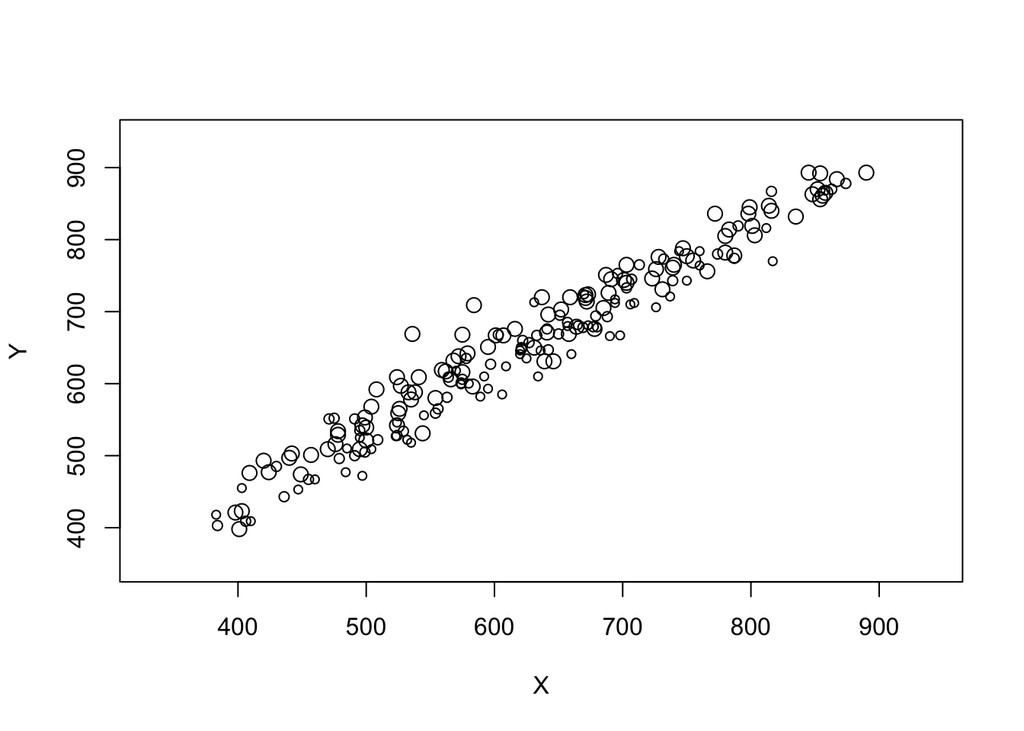

```r
data(api)
dstrat<-svydesign(id=~1,strata=~stype, weights=~pw, data=apistrat, fpc=~fpc)

svyplot(api00~api99, design=dstrat, style="bubble")
```

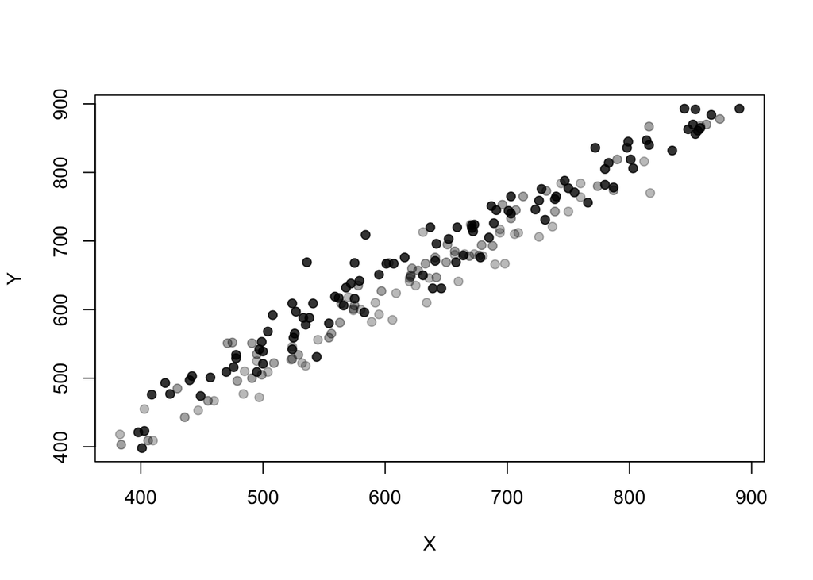

```r
svyplot(api00~api99, design=dstrat, style="transparent",pch=19)
```

The second strategy is used by the hexagonal binning plots and survey-weighted histograms. Hexagonal binning plots divide the screen on a hexagonal grid and show the number of points falling in each hexagon. The survey-weighted hexbin plot shows estimated population numbers in each cell.

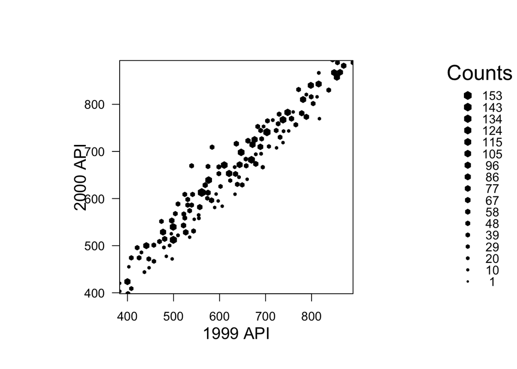

```r
library(hexbin)
svyplot(api00~api99, design=dstrat, style="hex", xlab="1999 API",ylab="2000 API")
```

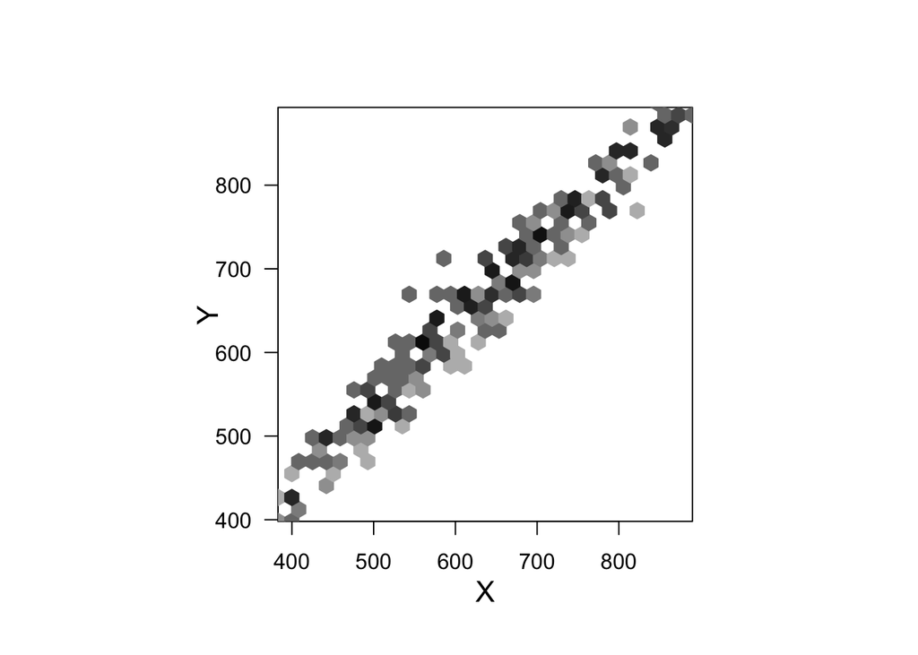

```r
svyplot(api00~api99, design=dstrat, style="grayhex",legend=0)
```

For discrete data, estimate a population table and plot the table. In the example below, sch.wide means if met school-wide growth target or not, comp.imp means if met comparable improvement target or not.

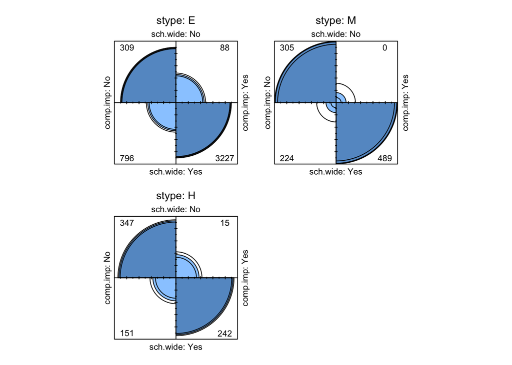

```r
fourfoldplot(svytable(~sch.wide+comp.imp+stype,design=dstrat,round=TRUE))
```

Another example uses the API data and compares the estimated cumulative distribution to the known population cumulative distribution

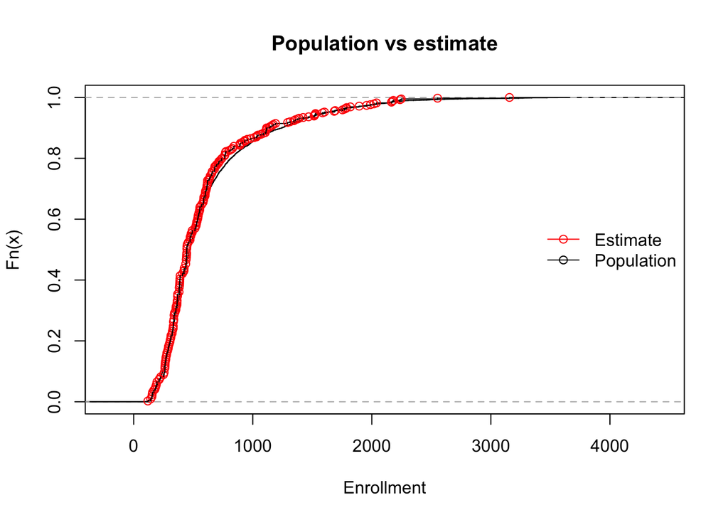

```r
data(api)
dstrat <- svydesign(id = ~1, strata = ~stype, weights = ~pw, data = apistrat,      fpc = ~fpc)
 cdf.est<-svycdf(~enroll+api00+api99, dstrat)
cdf.pop<-ecdf(apipop$enroll)

plot(cdf.pop, main="Population vs estimate",xlab="Enrollment")
lines(cdf.est[[1]],col.points="red")
legend("right",col=c("red","black"),pch=1, legend=c("Estimate","Population"),bty="n",lty=1)
```

###### Smoothing

This example uses data from PEAS Examplar 2, which examines internet use in Scotland from the Scottish Household Survey.

The graph of internet use by age and sex looks like the one in the PEAS examplar, but using svysmooth makes it much easier to produce

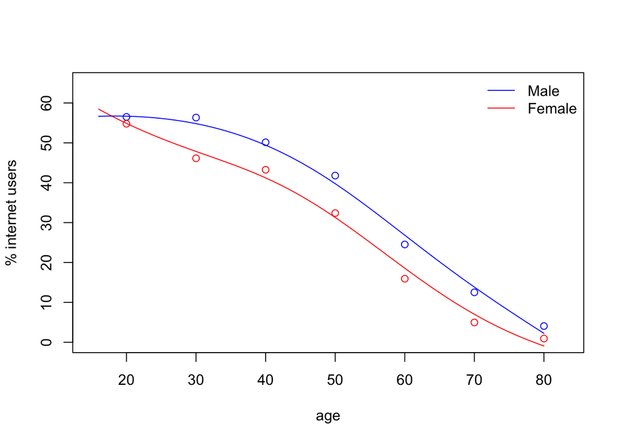

```r
load("ex2.RData")
shs.des <- svydesign(id=~PSU, weights=~GROSSWT,strata=~STRATUM,data=shs)

plot(c(15,83),c(0,65),type='n',xlab='age',ylab='% internet users')
legend("topright",lty=c(1,1),col=c("blue","red"),legend=c("Male","Female"),bty="n")
lf<-svysmooth(I(100*INTUSE)~AGE,subset(shs.des,SEX=="female" & !is.na(AGE)),bandwidth=10)
lines(lf,col="red")
lm<-svysmooth(I(100*INTUSE)~AGE,subset(shs.des,SEX=="male" & !is.na(AGE)),bandwidth=10)
lines(lm, col="blue")

shs.des <- update(shs.des, agegp=cut(AGE, c(0,25,35,45,55,66,75,Inf)))
means<-svyby(~INTUSE,~agegp+SEX,svymean,design=shs.des, na.rm=TRUE)
points((2:8)*10, means[1:7,3]*100,col="blue")
points((2:8)*10, means[7+1:7,3]*100,col="red")
```

### Reference

1. Survey analysis in R: https://r-survey.r-forge.r-project.org/survey/
2. Survey Data: Design and Examples: https://ehsanx.github.io/SPPH504007SurveyData/docs/
3. Complex Surveys: A Guide to Analysis Using R: https://www.amazon.com/Complex-Surveys-Guide-Analysis-Using/dp/0470284307
4. Analyzing Missing Data in Surveys: https://rstudio-pubs-static.s3.amazonaws.com/278191_4285e2382468496e937d895251eafdf9.html